Using MP2B as an example in this script.

First, process the scRNA data the usual way.

For now, include all cells, regardless of whether or not they have sufficient expression to be called by clonealign (with or without chr3).

```r
library(Seurat)
```

```r
library(ggplot2)
```

```r
RNA_path="../download/NYGC_collab/3prime_matrices/BOSTON_filtered_feature_bc_matrix/"
raw_counts <- Read10X(RNA_path)
seurat.obj <- CreateSeuratObject(raw_counts,min.cells=10,min.features=200)
seurat.obj[["percent.mito"]] <- PercentageFeatureSet(seurat.obj,pattern="^MT-")
seurat.obj <- subset(seurat.obj,percent.mito < 10) #Very few cells with higher mito than this, looking at distribution.
seurat.obj <- SCTransform(seurat.obj,conserve.memory=TRUE)
seurat.obj <- RunPCA(seurat.obj)
seurat.obj <- FindNeighbors(seurat.obj,reduction = "pca",dims = 1:30)
seurat.obj <- RunUMAP(seurat.obj,reduction = "pca",dims = 1:30)

umap_coords <- Embeddings(seurat.obj,reduction="umap")
write.csv(umap_coords,file="MP2B_only_umap_coords_very_lightly_filtered_RNA.csv",row.names=TRUE,quote=FALSE)
```

Read in clonealign output, both with and without chr3.

```r
excl_chr3 <- read.csv("MP2B_clonealign_calls_05.05.22.csv",header=TRUE,stringsAsFactors=FALSE)
incl_chr3 <- read.csv("MP2B_clonealign_calls_incl_chr3_05.05.22.csv",header=TRUE,,stringsAsFactors=FALSE)

incl_chr3_only_cells <- setdiff(incl_chr3$cell,excl_chr3$cell)
to_rbind <- data.frame(cell = incl_chr3_only_cells,clone = "no_call")
excl_chr3 <- rbind(excl_chr3,to_rbind)

rownames(excl_chr3) <- excl_chr3$cell
excl_chr3 <- excl_chr3[incl_chr3$cell,]

clone_info <- data.frame(excl_chr3 = excl_chr3$clone,
                         incl_chr3 = incl_chr3$clone,
                         row.names=excl_chr3$cell,
                         check.names=FALSE)

table(clone_info$excl_chr3,clone_info$incl_chr3)
```

```
##
##              Clone1 Clone2 unassigned
##   Clone1        997     28         71
##   Clone2          1    795         17
##   no_call       854    941        288
##   unassigned     52    103         99
```

We find that very few cells change their clone assignment whether we include or exclude chr3, but we get a lot more cells able to be assigned if we include it.

Let’s therefore use the calls incl. chr3 from here on out, and plot vs. the scRNA UMAP including all cells after light filtering (not just those from clonealign output).

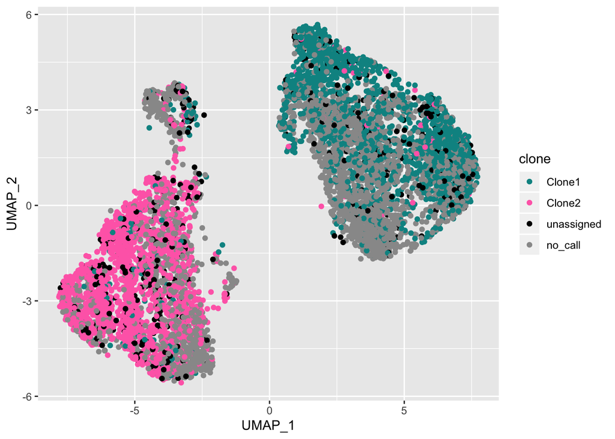

```r
umap_coords <- read.csv("MP2B_only_umap_coords_very_lightly_filtered_RNA.csv",header=TRUE,row.names=1,check.names=FALSE)

clonealign_missing_cells <- setdiff(rownames(umap_coords),rownames(clone_info))

to_rbind <- data.frame(excl_chr3 = rep("no_call",times=length(clonealign_missing_cells)),
                       incl_chr3 = "no_call",
                       row.names=clonealign_missing_cells)

clone_info <- rbind(clone_info,to_rbind)
clone_info <- clone_info[rownames(umap_coords),]

umap_coords$clone <- clone_info$incl_chr3

ggplot(umap_coords,aes(UMAP_1,UMAP_2,colour=clone)) + geom_point() + scale_colour_manual(values=c("#009292","#FF6DB6","#000000","#999999"))
```

We find that clone1 and clone2 show strong separation even when we include all cells in calculating UMAP (not just those output by clonealign).

It is likely that the gray cells in the green cluster show similar expression to Clone1 cells, while the gray cells in the pink cluster show similar expression to Clone2 cells.